# R Notebook

#DDG2P 데이터

```r
library(dplyr)
library(ggplot2)
library(tidyverse)
library(readr)
library(ggrepel)
library(cowplot)
```

## 주제 각 gene에 대한 developmental disorder 발생 빈도와 종류 및 pLI 분포

`pLI`의 정의는 The probability of being loss-of-function intolerant (intolerant of both heterozygous and homozygous loss-of-function variants) 입니다.

LOF(loss-of-function)을 견디지 못하는, 즉 해당 gene에 *LOF가 발생했을 때* *정상적으로 작동하지 않을 확률*을 말합니다.

gene 하나 하나 보기에는 gene 수가 너무 많은 관계로, developmental disorder 발생 빈도가 높은 gene을 선별적으로 추출했습니다.

gene의 pLI score과 developmental disorder 발생 빈도를 비교합니다. pLI score과 developmental disorder 발생 빈도 사이에 관계가 있음을 가설로 세웁니다. disorder 발생 빈도가 높은 gene일수록 LOF에 취약할 것이라 추측합니다.

한 번 알아보도록 하겠습니다.

## 설명

```r
#DDG2P 데이터를 `DDG`에 저장합니다.
DDG<- read.delim("DDG2P_24_9_2019.with_pLI.txt", sep='\t', header = T,)
```

```r
#DDG에서 developmental disorder 발생 빈도가 5를 초과하는 gene을 선별합니다.
gg <- DDG %>% select(gene.symbol) %>% group_by(gene.symbol) %>% dplyr::count() %>% filter(n>5) %>% select(gene.symbol) %>% .$gene.symbol
```

```r
#gene별로 developmental disorder 발생 빈도와 pLI를 비교합니다.
#대체로 developmental disorder 발생 빈도가 높은 gene은 pLI 또한 1에 가깝다는 것을 알 수 있습니다.
p1 <- DDG[DDG$gene.symbol %in% gg, ] %>% select(gene.symbol, disease.name, pLI) %>% group_by(gene.symbol, pLI) %>% dplyr::count() %>%
  ggplot(aes(n, pLI)) +
  geom_text_repel(aes(label = gene.symbol), show.legend = FALSE) +
  geom_point(aes(color = gene.symbol), show.legend = FALSE) +
  coord_flip() +
  xlab("Developmental Disorder Frequency") +
  ylab("pLI (Probability of being loss-of-function intolerant)") +
  xlim(0, 11) +
  ggtitle("Relationship between DD Frequency and pLI")
```

```r
#가장 많은 gene과 연관된 developmental disorder 종류
disease_freq <- DDG %>% select(disease.name) %>% group_by(disease.name) %>% dplyr::count()
top_six_freq <- disease_freq[order(-disease_freq$n) ,] %>% head()
##플로팅
p2_1 <- top_six_freq %>%
  ggplot(aes(reorder(disease.name, n), n)) +
  geom_col(fill = "#CC3399") +
  ylab("Occurrence Frequency in genes") +
  xlab("Developmental Disorder") +
  coord_flip() +
  scale_x_discrete(labels = c("AUTISM", "LEIGH SYNDROME", "ZELLWEGER SYNDROME", "EPILEPTIC
  ENCEPHALOPATHY", "INTELLECTUAL
  DISABILITY", "AUTOSOMAL RECESSIVE
                     MENTAL RETARDATION")) +
  ggtitle("Top six Most Frequent Developmental Disorders (in all genes)") +
  theme(plot.title = element_text(size = 10))
```

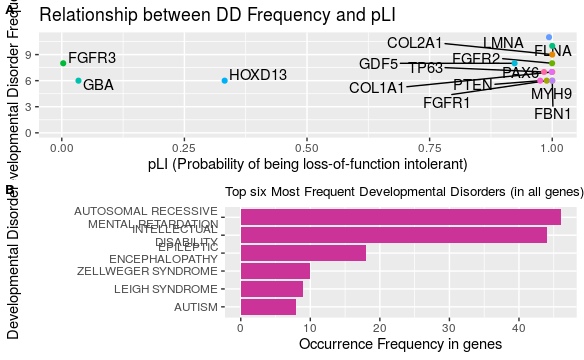

```r
#플롯 합치기
great <- plot_grid(p1, p2_1, labels = c('A', 'B'), label_size = 10, ncol = 1)




#높이를 길게 저장했습니다.
ggsave("DDD2P.DiseaseFreqWithpLI.20191017.jpg", great, height = 10, width = 8)



great
```

## 분석

developmental disorder 발생 빈도가 높은 gene은 대체로 pLI score가 1에 가깝게 나타났습니다. disorder 발생 빈도가 높은 것과 LOF mutation에 취약한 것 사이에 어느 정도 관계가 있음을 분석해 볼 수 있었습니다.

## 한계

모든 gene을 사용하지 않았고, 모든 gene을 사용하여 분석을 했을 때 disorder 발생 빈도가 높은 gene만 선별하여 사용했을 때보다 발생 빈도와 pLI score간의 상관성이 보다 낮게 나타났습니다.

발생 빈도가 낮을 경우 pLI score와 연관이 낮거나, 혹은 발생 빈도가 높은 gene과 pLI score 사이의 비례적 연관성이 우연히 나타났을 수도 있습니다.

## 더 나아가

발생 빈도가 높은 경우에만 효과가 있는지에 대해 더 분석해 볼 필요가 있습니다. 또한 pLI score와 disorder의 종류, 그리고 발생 빈도가 관련이 있는지 확인해 볼 필요가 있습니다.

### Term 정리

`Null` : where observed ≈ expected (LoF variation is tolerated) LoF 잘 견딘다.

`Recessive` : where observed ≤ 50% of expected (heterozygous LoFs are tolerated) 대립유전자 한 쪽만 잘못된 거 잘 견딤. 즉 LoF 변이 발생이 열성.

`Haploinsufficient` : where observed < 10% of expected (heterozygous LoFs are not tolerated) 대립유전자 한 쪽만 잘못되어도 못 견딤. 즉 LoF 변이 발생이 우성.

`allele` : 대립유전자. 한 쌍의 염색체가 있을 때 각 염색체에 있는 대립형질의 유전자..

`heterozygous` : 다른 대립유전자. 이형접합체. Rr. rR.

`homozygous` : 같은 대립유전자.. 동형접합체. RR. rr.